# 机器学习工程师纳米学位

### 可选问题 - 预测北京房价

（本题结果不影响项目是否通过）通过上面的实践，相信你对机器学习的一些常用概念有了很好的领悟和掌握。但利用70年代的波士顿房价数据进行建模的确对我们来说意义不是太大。现在你可以把你上面所学应用到北京房价数据集中`bj_housing.csv`。

免责声明：考虑到北京房价受到宏观经济、政策调整等众多因素的直接影响，预测结果仅供参考。

这个数据集的特征有：

- Area：房屋面积，平方米
- Room：房间数，间
- Living: 厅数，间
- School: 是否为学区房，0或1
- Year: 房屋建造时间，年
- Floor: 房屋所处楼层，层

目标变量：

- Value: 房屋人民币售价，万

你可以参考上面学到的内容，拿这个数据集来练习数据分割与重排、定义衡量标准、训练模型、评价模型表现、使用网格搜索配合交叉验证对参数进行调优并选出最佳参数，比较两者的差别，最终得出最佳模型对验证集的预测分数。

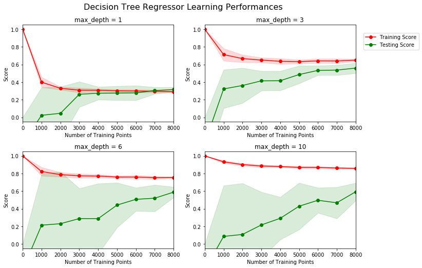

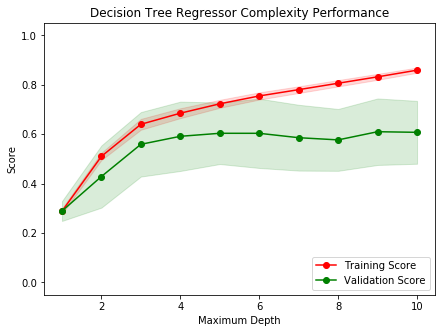

```
The final model has a max_depth of  9
Model Score on Testing Set:  0.484820304883
```

```python
# Beijing Housing Price Prediction Model

import numpy as np
import pandas as pd
from sklearn.model_selection import ShuffleSplit
from sklearn.model_selection import train_test_split
from sklearn.model_selection import GridSearchCV
from sklearn.metrics import r2_score
from sklearn.metrics import make_scorer
from sklearn.tree import DecisionTreeRegressor


data = pd.read_csv('bj_housing.csv')
prices = data['Value']
features = data.drop('Value', axis=1)
X_train, X_test, y_train, y_test = train_test_split(features, prices, train_size=0.8)

# Train the model, and using GridSearch + K-Fold CV for model parameter tuning.
def fit_model(X, y):
    cv_sets = ShuffleSplit(n_splits=10, test_size=0.2, random_state=0)
    regressor = DecisionTreeRegressor(random_state=0)
    params = {'max_depth': np.arange(1, 11)}
    scoring_fnc = make_scorer(r2_score)
    grid = GridSearchCV(estimator=regressor, param_grid=params, scoring=scoring_fnc, cv=cv_sets)
    grid.fit(X, y)
    return grid.best_estimator_


model = fit_model(X_train, y_train)
md = model.get_params()['max_depth']
vs.ModelLearning(features, prices)
vs.ModelComplexity(X_train, y_train)
print "The final model has a max_depth of ", md


# Evaluate the final model
y_pred = model.predict(pd.DataFrame(X_test))
print "Model Score on Testing Set: ", r2_score(y_pred, y_test)


vs.PredictTrials(features, prices, fit_model, )
```

你成功的用新的数据集构建了模型了吗？他能对测试数据进行验证吗？它的表现是否符合你的预期？交叉验证是否有助于提升你模型的表现？

**答案：**

- 由上图可见，预测北京房价的模型在测试数据集下的性能分数是0.48，达到这个性能所用的决策树模型深度是9。

```python
def robust_test(features, prices, models, iteration):
    depth = []
    score = []
    for x in range(iteration):
        X_train, X_test, y_train, y_test = train_test_split(features, prices, train_size=0.8, random_state=x)
        model = fit_model(X_train, y_train)
        depth.append(model.get_params()['max_depth'])
        y_pred = model.predict(pd.DataFrame(X_test))
        score.append(r2_score(y_pred, y_test))
    return depth, score

(depth, score) = robust_test(features, prices, fit_model, 10)
print "\nModel tree max depth Statistics over 10 run: \n", pd.Series(depth).describe()
print "\nModel R2 Score Statistics over 10 run: \n", pd.Series(score).describe()
```

```
Model tree max depth Statistics over 10 run:
count    10.000000
mean      6.500000
std       2.173067
min       3.000000
25%       5.250000
50%       6.000000
75%       8.750000
max       9.000000
dtype: float64

Model R2 Score Statistics over 10 run:
count    10.000000
mean      0.450899
std       0.222173
min      -0.028896
25%       0.341710
50%       0.477015
75%       0.625357
max       0.700067
dtype: float64
```

**答案：**

- 问：它的表现是否符合你的预期？

  我多跑了几次，发现模型的性能并不稳定，于是写了一个测试模型鲁棒性能的函数，检查独立构造模型10次中每次最终模型的深度`depth`和针对测试集的分数`score`。然后发现模型最差的时候甚至能够得负分，就是说这时候模型还不如直接对原数据集平均得到的结果准确...不过最好的时候模型还能达到0.7分的高分。考虑到已经使用了GridSearch和K-Fold CV，因此这种不稳定的现象应该不是模型本身参数的问题，也不是数据集本身划分不均匀导致的，而是**数据集提供的特征根本就不够导致的**（详见回答问题8的**机器学习所用的数据集的2个大前提**总结）。影响北京的房价的因素肯定远远不止数据集中这6个特征，还要考虑到政策调控和宏观经济走势的影响。因此这个数据集训练出来的模型的准确度和稳定性都不会太高。
- 问：交叉验证是否有助于提升你模型的表现？

  使用ShuffleSplit交叉验证还是很重要的，它能确保你在对训练数据集的建模结果更为准确。

如果你是从零开始构建机器学习的代码会让你一时觉得无从下手。这时不要着急，你要做的只是查看之前写的代码，把每一行都看明白，然后逐步构建你的模型。当中遇到什么问题也可以在我们论坛寻找答案。也许你会发现你所构建的模型的表现并没有达到你的预期，这说明机器学习并非是一项简单的任务，构建一个表现良好的模型需要长时间的研究和测试。这也是我们接下来的课程中会逐渐学到的。